# Chap7_4

J.H AHN

2021 12 16

## 7.4 Some useful predictors

시계열 데이터의 regression을 사용할 때 자주 발생하는 유용한 몇 가지 predictor들이다.

### Trend

추세(trending)는 시계열 데이터의 공통 요소이다. 선형 추세는 간단하게 $x_{1,t}=t$ 예측변수를 사용하여 모델링 할 수 있다.

$$y_{t}= \beta_0+\beta_1t+\varepsilon_t,$$

여기에서 $t=1,\dots,T$이고, `TSLM()`함수 안에서 사용할 수 있는 `trend()`함수로 확인할 수 있다.  
이것은 모델의 비선형 추세를 다루는 Chap7_7에서 상세하게 다룬다.

### Dummy variables

지금까지는 각 예측변수가 숫자값을 가진다고 가정했다. 하지만 예측변수가 두개의 값(예를 들어 “YES” and “NO”)만 취하는 범주형 변수일 경우에는 “YES”에 해당하는 값 1과 “NO”에 해당하는 값 0을 취하는 **dummy variable**을 생성하여 처리할 수 있다.

더미변수를 사용하여 데이터의 이상치를 설명할 수도 있다.  
더미변수는 이상치를 생략하는 대신 그 효과를 제거하는데 사용하는데 이 경우 이상치에 대해서는 1을 가지고 다른 모든 경우에 대해서는 0을 가진다.  
특별한 이번트가 발생하는 경우를 처리할 때 이러한 기법을 응용할 수 있다.  
예를 들어 브라질로 오는 연간 관광객을 예측할 때 2016년 올림픽의 영향을 고려할 수 있고, 에콰도르의 소매점 판매량을 예측할 때 2014년 지진의 영향을 고려하는데 사용할 수도 있다.

범주가 3개 이상인 경우 변수는 전체 범주 수보다 하나 작은 더미변수를 생성하여 사용하면 된다.  
예를 들어 요일의 경우 일 ~ 토요일까지 총 7일이지만 더미변수는 6개만 생성하면 된다. 왜냐하면 모두 0이 들어갔다면 일요일로 보면 되기 때문이다.

factor variable을 `TSLM()`함수로 처리하면 이를 자동으로 더미변수로 만들어 처리한다.

### Seasonal dummy variables

요일 데이터를 처리하는 경우 아래와 같이 더미변수를 생성할 수 있다.

[output not shown]

7개의 범주는 6개의 더미변수만으로 만들 수 있다.  
일곱번째 범주(이 경우에는 일요일)는 더미변수가 모두 0이 될 때로 지정되기 때문이다.

많은 초보자들이 7개의 범주를 만들기 위해 7개의 더미변수를 만드는 경우가 있는데 이 때문에 regression이 안 되는 경우가 발생한다.  
이런 현상을 “더미 변수 트랩(dummy variable trap)”이라 한다.

절편도 포함되어야 한다면 추정할 parameter가 너무 많아진다.  
일반적인 규칙은 범주보다 하나 작은 수의 더미 변수를 사용하는 것이다.  
따라서 분기별 데이터의 경우에는 3개의 더미 변수를 사용하고, 월별 데이터의 경우에는 11개의 더미변수를, 요일별 데이터의 경우는 6개의 더미변수를 사용한다.

더미변수와 관련된 각 계수의 해석은 생략된 범주에 대한 해당 범주의 효과를 측정결과이다.  
위의 예에서 월요일과 관계된 $d_{1,t}$계수는 일요일의 영향과 비교하여 예측변수에 대한 월요일의 영향을 측정한다.

아래는 호주 맥주 생산의 분기별 계절성을 가진 더미변수 해석의 예이다.

`TSLM()`함수에서 `season()`함수를 사용하면 자동으로 이러한 계절성을 처리한다.

### Example Australian quarterly beer production

호주의 분기별 맥주 생산을 다시 가져와서 예제로 사용한다.

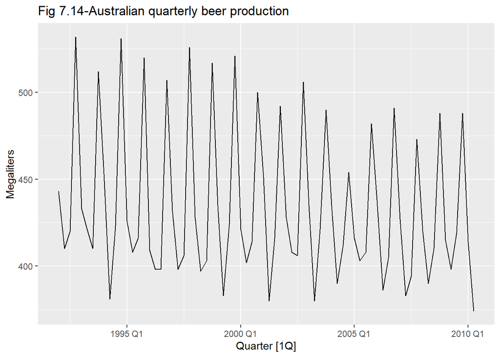

```r
recent_production <-
    aus_production %>%
    filter(year(Quarter) >= 1992)

recent_production %>%
    autoplot(Beer) +
    labs(title = "Fig 7.14-Australian quarterly beer production",
         y = "Megaliters")
```

맥주 생산량을 예측하길 원하므로 선형 추세를 가진 regression model과 분기별 더미 변수를 이용하여 모델링을 한다.

```r
fit_beer <- recent_production %>%
model(TSLM(Beer ~ trend() + season()))

report(fit_beer)
```

```
## Series: Beer
## Model: TSLM
##
## Residuals:
##      Min       1Q   Median       3Q      Max
## -42.9029  -7.5995  -0.4594   7.9908  21.7895
##
## Coefficients:
##                Estimate Std. Error t value Pr(>|t|)
## (Intercept)   441.80044    3.73353 118.333  < 2e-16 ***
## trend()        -0.34027    0.06657  -5.111 2.73e-06 ***
## season()year2 -34.65973    3.96832  -8.734 9.10e-13 ***
## season()year3 -17.82164    4.02249  -4.430 3.45e-05 ***
## season()year4  72.79641    4.02305  18.095  < 2e-16 ***
## ---
## Signif. codes:  0 '***' 0.001 '**' 0.01 '*' 0.05 '.' 0.1 ' ' 1
##
## Residual standard error: 12.23 on 69 degrees of freedom
## Multiple R-squared: 0.9243,  Adjusted R-squared: 0.9199
## F-statistic: 210.7 on 4 and 69 DF, p-value: < 2.22e-16
```

`trend()`함수와 `season()`함수는 `TSLM()`함수 안에서만 작동되는 함수이다.

값을 보면 분기별로 약 0.34megaliter씩 생산량이 감소하고 있음을 알 수 있다.  
평균적으로 두번째 분기에는 첫번째 분기 대비 -34.66megaliter가 감소하고 세번째 분기에는 첫번째 분기 대비 17.82megaliter가 감소, 네번째 분기에는 반대로 72.80megaliter가 증가하는 것으로 나타났다.

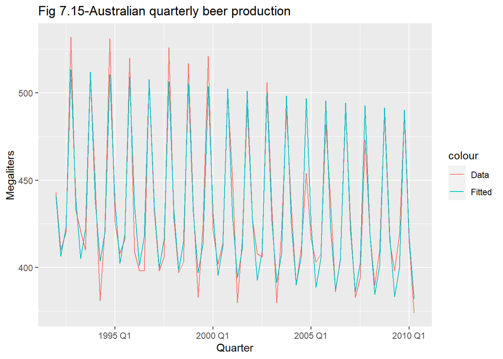

```r
augment(fit_beer) %>%
    ggplot(aes(x = Quarter)) +
    geom_line(aes(y = Beer, color = "Data")) +
    geom_line(aes(y = .fitted, color = "Fitted")) +
    labs(title = "Fig 7.15-Australian quarterly beer production",
         y = "Megaliters")
```

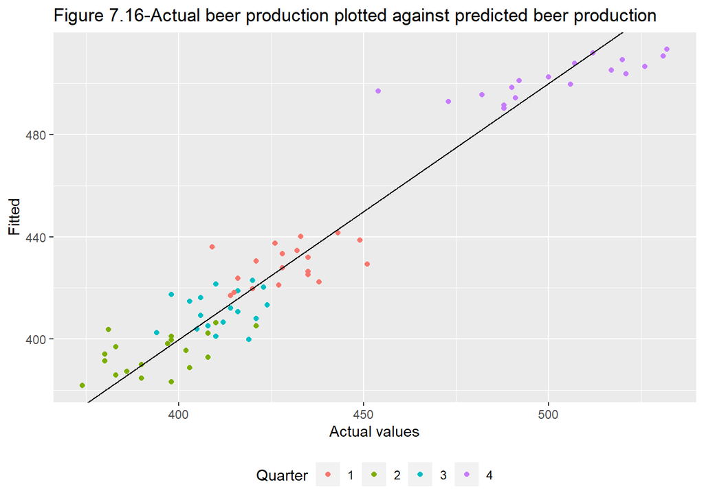

```r
augment(fit_beer) %>%
    ggplot(aes(x = Beer, y = .fitted,
               color = factor(quarter(Quarter)))) +
    geom_point() +
    geom_abline() +
    labs(title = "Figure 7.16-Actual beer production plotted against predicted beer production",
         x = "Actual values", y = "Fitted",
         color = "Quarter") +
    theme(legend.position = "bottom")
```

### Intervention variables

예측할 변수에 영향을 미칠 수 있는 일들을 모델링 하는 것이 종종 필요하다.  
예를 들어 경쟁사의 활동. 광고비, 쟁의행위 등이 모두 영향을 미칠 수 있는 요인이다.

효과가 일정 기간동안만 지속된다면 “spike”변수를 사용한다.  
이것은 개입 기간에는 1의 값을 취하고 다른 곳에서는 0을 취하는 더미변수이다.  
spike variable은 이상치를 처리하기 위한 더미 변수와 같다.

혹은 즉각적이고 영구적인 영향을 미치는 경우, 개입으로 이해 수준이 달라지는 경우라면 “step”변수를 사용한다.  
step variable은 개입 이전에는 0, 개입 이후부터는 1의 값을 취한다.

영구적인 효과의 또다른 형태는 기울기를 바꾸는 것이다.  
여기서 개입하는 이벤트들은 선형 추세의 조각들을 이용하여 처리한다.  
개입 시점에 추세가 구부러진다면 비선형적이 되었다는 의미가 된다.  
이에 대해서는 Chap7_7에서 상세하게 다룬다.

### Trading days

한 달의 거래일수는 다를 수 있고, 이로 인해 판매 데이터의 분석결과가 달라질 수 있다.  
이를 위해 매월 거래일수를 예측변수로 포함할 수 있다.

특정한 요일에 다른 효과를 주기 위한 대안에는 아래와 같은 예측변수가 있다.

$$\begin{align*}
x_{1} &= \text{number of Mondays in month;} \\
x_{2} &= \text{number of Tuesdays in month;} \\
& \vdots \\
x_{7} &= \text{number of Sundays in month.}
\end{align*}$$

### Distributed lags

종종 광고에 쓰인 지출을 예측 변수로 포함하는 데이터 분석에 유용하다.  
광고는 특성상 실제 지출 시점 이후에 효과가 나타나고 일정 시간 효과가 지속되기 때문에 시차를 고려해야 한다.

따라서 아래와 같은 예측 변수를 사용할 수 있다.

$$\begin{align*}
x_{1} &= \text{advertising for previous month;} \\
x_{2} &= \text{advertising for two months previously;} \\
& \vdots \\
x_{m} &= \text{advertising for $m$ months previously.}
\end{align*}$$

지연이 증가함에 따라 계수가 감소되도록 하는 것이 일반적인데 이 책에서 다루는 범위를 벗어나는 내용이라 상세하게 기술하지 않는다.

### Easter

부활절은 매년 같은 날짜에 열리지 않고 그 효과가 며칠 동안 지속된다는 점에서 대부분의 다른 공휴일들과 다르다.  
이 경우 휴일이 특정 기간에 해당되면 값이 1일고 그렇지 않을 경우 0인 더미변수를 사용할 수 있다.

월별데이터의 경우 부활적이 3월이면 더미변수는 3월에 1을 취하고 4월에 있으면 더미변수는 4월에 1을 취한다.  
부활절이 3월에 시작하여 4월에 끝나면 더미변수는 월간에 비례하여 분할한다.

### Fourier series

아주 긴 계절동안 계절성 더미 변수를 사용하는 것의 대안으로 푸리에 항(Fourier terms)을 사용하는 방법이 있다. 푸리에 변환은 모든 주기함수를 sine과 cosine항으로 근사할 수 있다는 것이다.

만약 계절성 주기(seasonal period)가 $m$이라면 첫번째 Fourier terms은 아래와 같이 나타난다.

$$x_{1,t} = \sin\left(\textstyle\frac{2\pi t}{m}\right),
x_{2,t} = \cos\left(\textstyle\frac{2\pi t}{m}\right),
x_{3,t} = \sin\left(\textstyle\frac{4\pi t}{m}\right),$$
$$x_{4,t} = \cos\left(\textstyle\frac{4\pi t}{m}\right),
x_{5,t} = \sin\left(\textstyle\frac{6\pi t}{m}\right),
x_{6,t} = \cos\left(\textstyle\frac{6\pi t}{m}\right),$$

만약 월별 주기성을 가진다면 처음 11개의 예측변수를 사용하면 11개의 더미변수를 사용할 때와 똑같은 예측값을 얻을 수 있다.

특히 계절성 주기$m$이 크다면 Fourier terms을 사용해서 더미변수보다 더 적은 수의 예측변수를 사용하여 결과를 얻을 수 있다. 예를 들어 $m\approx 52$인 주간 데이터에 유용하게 사용할 수 있다.  
분기별 데이터와 같은 짧은 계절성 주기를 가진 데이터라면 Fourier terms을 사용하는 것이 계절성 더미변수를 사용하는 것에 비해 큰 장점을 가지지는 않는다.

이러한 Fourier terms은 `fourier()`함수를 사용하여 만들 수 있다.  
예를 들어 호주 맥주 생산 데이터로 모델링을 해보자.

```r
fourier_beer <-
    recent_production %>%
    model(TSLM(Beer ~ trend() + fourier(K = 2)))

report(fourier_beer)
```

```
## Series: Beer
## Model: TSLM
##
## Residuals:
##      Min       1Q   Median       3Q      Max
## -42.9029  -7.5995  -0.4594   7.9908  21.7895
##
## Coefficients:
##                     Estimate Std. Error t value Pr(>|t|)
## (Intercept)        446.87920    2.87321 155.533  < 2e-16 ***
## trend()             -0.34027    0.06657  -5.111 2.73e-06 ***
## fourier(K = 2)C1_4   8.91082    2.01125   4.430 3.45e-05 ***
## fourier(K = 2)S1_4 -53.72807    2.01125 -26.714  < 2e-16 ***
## fourier(K = 2)C2_4 -13.98958    1.42256  -9.834 9.26e-15 ***
## ---
## Signif. codes:  0 '***' 0.001 '**' 0.01 '*' 0.05 '.' 0.1 ' ' 1
##
## Residual standard error: 12.23 on 69 degrees of freedom
## Multiple R-squared: 0.9243,  Adjusted R-squared: 0.9199
## F-statistic: 210.7 on 4 and 69 DF, p-value: < 2.22e-16
```

`fourier()`함수 안에 쓰인 `K` argument는 몇 개의 Sin, cos term이 포함되어 있는지를 입력하는 것이다. 최대 $K$값은 $K=m/2$으로 정의된다. (여기서 $m$은 seasonal period를 의미한다.)  
최대값을 사용할 경우에는 계절성 더미변수를 사용한 결과와 동일한다.

만약에 단 두개의 Fourier terms ($x_{1,t}$, $x_{2,t}$)을 사용했다면 계절 패턴은 간단한 사인파(sine wave)의 형태를 가질 것이다.  
Fourier terms을 가지는 회귀 모델을 **harmonic regression**이라 부르는데 이는 연속적인 Fourier terms은 첫 두 Fourier terms의 harmonic을 보이기 때문이다.

**Harmonic(고조파)**는 원천 추파수(Fundamental frequency)의 배수 주파수 성분을 의미함.